# World Happiness Report from year 2005-2021

### A scatter plot of each Continent showing social support on the x-axis and life ladder on the y-axis

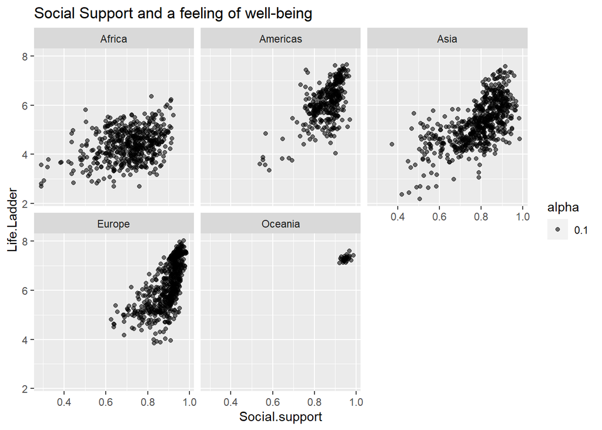

- It looks like another positive relationship. As social support increases, happiness scores increase as well. This is consistent in each continent.

Let’s explore one more category: Freedom to make life choices.

- Freedom to make life choices- “Are you satisfied with your freedom to choose what you do with your life?”

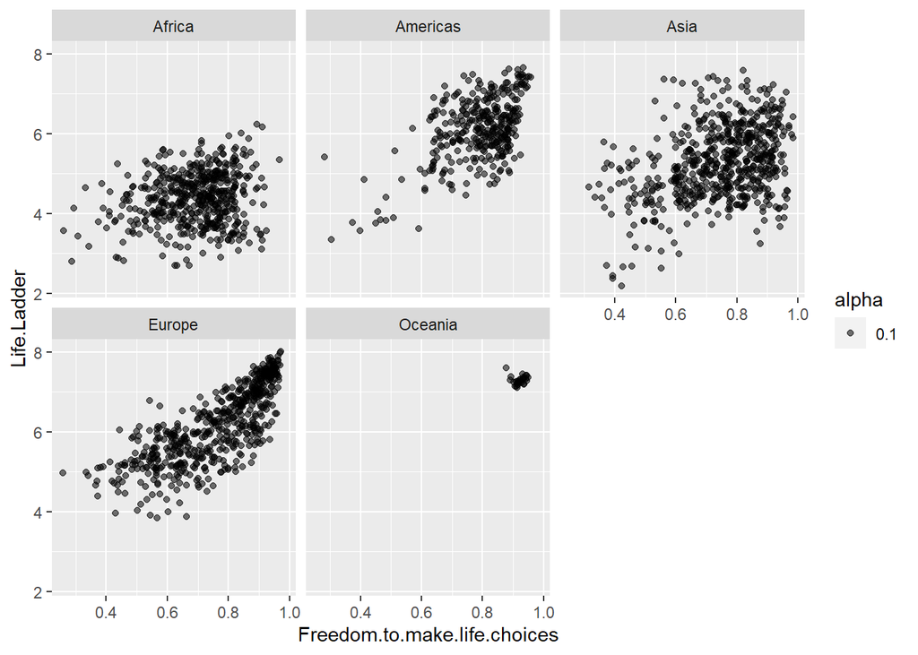

```r
data1 %>%
  ggplot(mapping = aes(x = Freedom.to.make.life.choices,
                       #change alpha transparency secondary to overlap
                       y = Life.Ladder,alpha=.1)) +
                      #use facet_wrap to look at each continent separately
                      geom_point()+facet_wrap(~Continent)
```

- As freedom to make life choices increases, the Life.Ladder scores increase as well. This demonstrates another positive, increasing relationship.

## Summary

- In analyzing the results we discovered a trend that the Nordic countries of Finland, Denmark, Switzerland and Norway had the highest average happiness scores. The countries of South Sudan and Afghanistan had the lowest average happiness scores. We saw a plot of happiness scores related to continents and arranged them in ascending order. We found a positive, increasing, relationship with GDP, Life Expectancy, Social Support, and the Freedom to make life choices. There was a negative relationship with one factor. As perception of corruption increased, the happiness scores decreased. The data did not demonstrate a clear relationship between confidence in the national government and well-being.
- Some important things to consider are that the poll results are subjective and could be swayed by cultural norms. Some people don’t feel comfortable rating their government or freedoms. Another thing to consider is that the poll is largely taken over the telephone and it is not clear if the homeless, prisoners, and nursing home residents were able to be reached.
- I purposefully did not compare pre-pandemic numbers to post numbers because the dataset ends in 2021 and the pandemic was still ongoing at that point. Also, it is not clear how scores were collected during lockdown/quarantine. Once the 2023 numbers are released it would be interesting to compare pre, during, and post numbers.